# Some recent analysis and modeling applied to COVID-19

2020-04-19 21:07:24

## Introduction

- The following is a mix of projects I have been involved with on COVID-19.
- Some are research focused, some are more operational.
- I’ll stop after each small project so we can discuss. Also feel free to ask questions during the presentation.

## Assessing the impact of a symptom-based mass screening and testing intervention during a novel infectious disease outbreak: The case of COVID-19

## Motivation

- China and other countries used a mass screening and testing intervention (MSTI) approach.
- If MSTI overloads the healthcare system, and especially if conditions in testing facilities are not safe, this could lead to additional transmission.
- What are the benefits and risks of MSTI and under what conditions is it a good strategy?

## Model

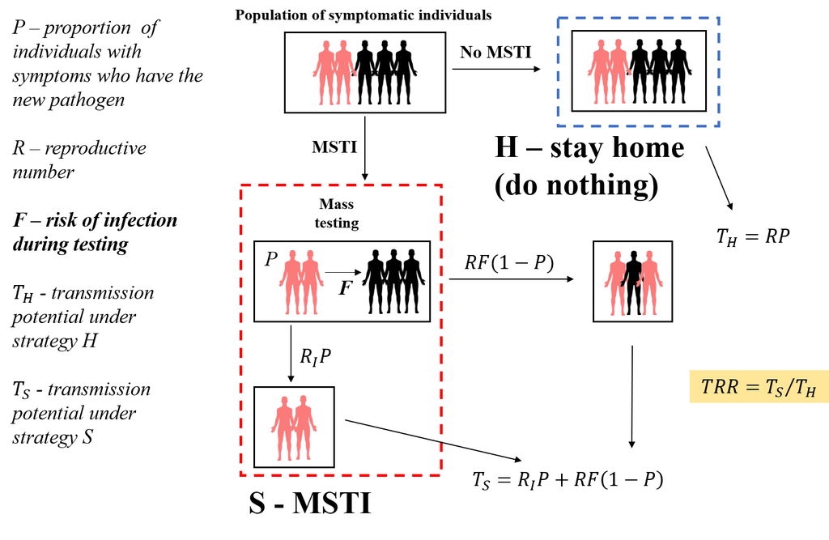

## Result

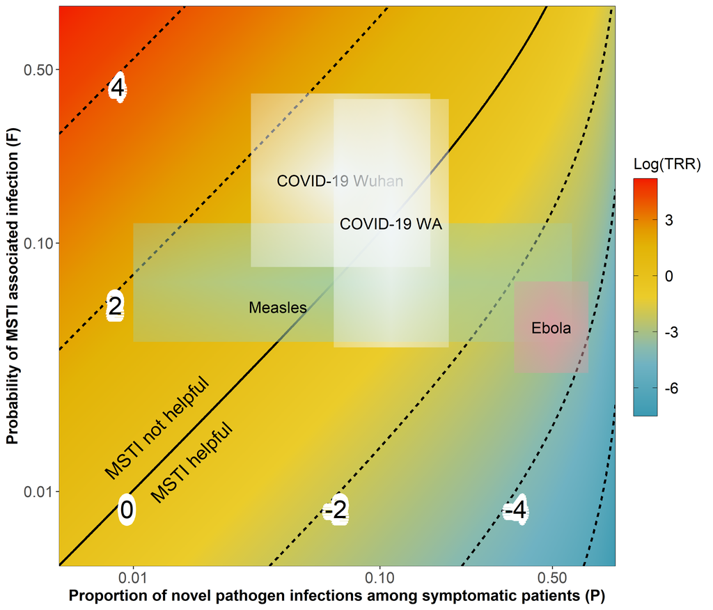

## Acknowledgments and More Information

- Collaborators: Yang Ge, Brian Kenneth McKay, Shengzhi Sun, Feng Zhang
- Prep-print: https://doi.org/10.1101/2020.02.20.20025973

## If long-term suppression is not possible, how do we minimize mortality for COVID-19 and other emerging infectious disease outbreaks?

## Motivation

- In some countries/areas, COVID-19 suppression might not be achievable.
- If we have to contend with spread, how do we ensure that the lowest number of people die?
- We explored a simple model with age-structured risk of mortality to explain conceptually how best to implement interventions.

## Model

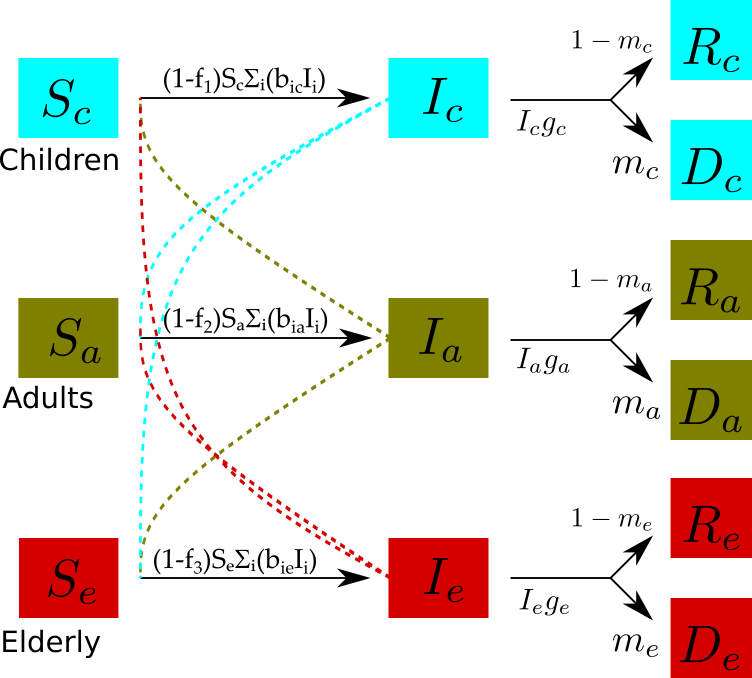

## Result

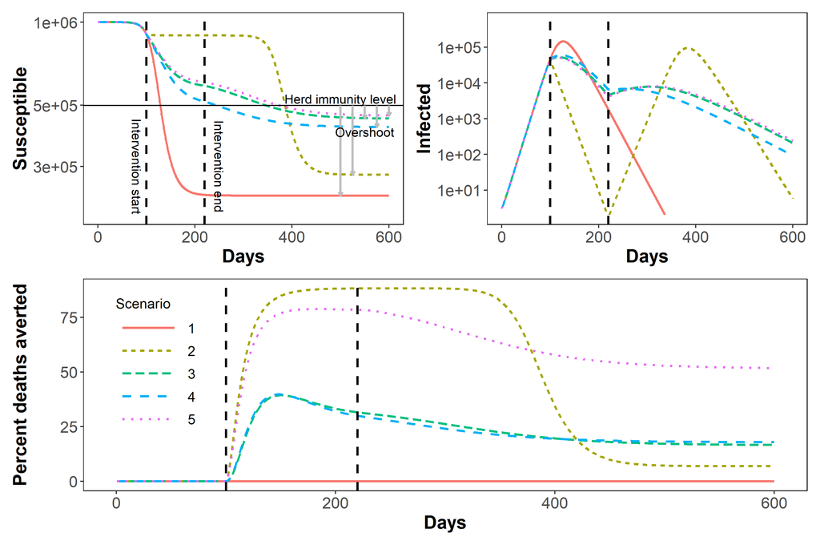

S1 - no interventions. S2 - strong interventions. S3-S5, interventions mainly targeting children/adults/elderly.

## Acknowledgments and More Information

- Collaborators: Joel Miller, Yang Ge, Isaac Chun-Hai Fung
- Prep-print: https://doi.org/10.1101/2020.03.13.20034892
- See also: Handel et al 2007 PRSB; Fung et al 2012 PLoS One.

## A COVID-19 Tracker

## Motivation

- There are lots of COVID-19 visualization/trackers out there.
- None that I looked at (<10%?) did exactly what I wanted.
- With the help of a few students, we built our own.
- We implemented it using R/Shiny.

## Result

- https://shiny.ovpr.uga.edu/yact/

## Acknowledgments and More Information

- Collaborators: Robbie Richards and William Norfolk
- See also: http://2019-coronavirus-tracker.com/

## Forecasting cases and hospitalizations in the US

## Motivation

- We want to know how many cases and hospitalizations to expect.
- Initially were asked by GA governor’s office. Want to now extend to all US states.

## Model

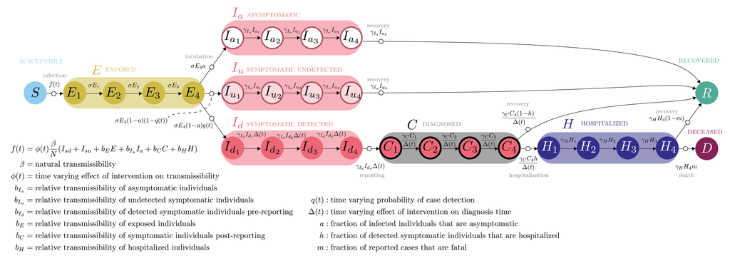

## Result

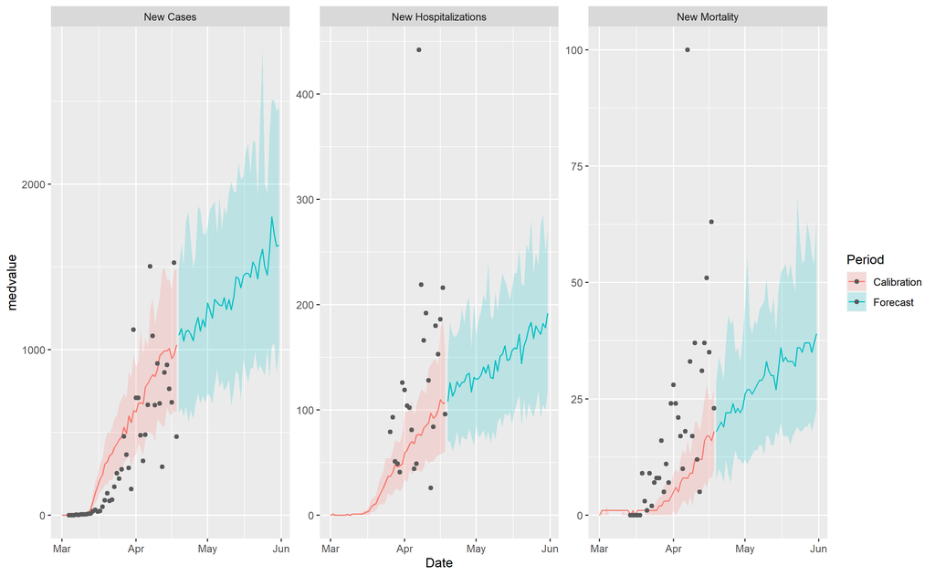

## Acknowledgments and More Information

- Collaborators: John Drake, Andrew Tredennick, Eamon O’Dea, Tierney O’Sullivan
- More information: https://github.com/CEIDatUGA/COVID-stochastic-fitting

## Airborne Transmission of COVID-19: Epidemiologic Evidence from Two Outbreak Investigations

## Motivation

- The potential of airborne transmission of SARS-CoV-2 is of great importance.

## Methods

- Data from a COVID-19 outbreak entailing 2 buses (bus #2 containing an infected person) going to a temple for an (outdoor) religious ceremony.

## Result

|  | **Cases** | **Total** | **Attack rate (95% CI)** | **Relative Risk (95% CI)** |
| --- | --- | --- | --- | --- |
| Bus #1 | 0 | 60 | 0 (0–6.0) | 1 (Reference) |
| Bus #2 | 23 | 67 | 34.3 (24.1–46.3) | 41.5 (2.6–669.5) |
| All individuals at ceremony except bus #2 | 7 | 232 | 3.0 (1.3–6.2) | … |
| Overall | 30 | 299 | 10.0 (7.1–14.0) | … |
| Bus #2 Low-risk zones (rows 1-4, 12-15) | 9 | 34 | 26.5 (14.4–43.3) | 1 (Reference) |
| Bus #2 High-risk zone (rows 5-11) | 14 | 33 | 42.4 (27.2–59.2) | 1.6 (0.8–3.2) |

## Acknowledgments and More Information

- Collaborators: Shen, Ye and Li, Changwei and Dong, Hongjun and Wang, Zhen and Martinez, Leonardo and Sun, Zhou and Chen, Zhiping and Chen, Enfu and Ebell, Mark and Wang, Fan and Yi, Bo and Wang, Haibin and Wang, Xiaoxiao and Wang, Aihong and Chen, Bingbing and Qi, Yanling and Liang, Lirong and Li, Yang and Ling, Feng and Chen, Junfang and Xu, Guozhang
- Prep-print: https://dx.doi.org/10.2139/ssrn.3567505 (a second outbreak and more details are given in the paper)

## A Cluster of COVID-19 Infections Indicating Person-To-Person Transmission among Casual Contacts from Social Gatherings: An Outbreak Case-Contact Investigation

## Motivation

- Understand transmission potential in different settings

## Methods

- Data from several infector-infectee interactions.
- Multiple interactions and transmissions among family members.
- A few interactions among casual contacts.

## Result

| **Event** | **Date** | **Infectious present** | **Susceptible present** | **Upper bound of possible new infections** | **Secondary attack rate (%)** |
| --- | --- | --- | --- | --- | --- |
| Lunch | Jan 18 | 2 | 7 | 2 | 2/7 = 29% |
| Birthday party | Jan 19 | 2 | 30 | 0 | 0/30 = 0% |
| Wedding Party day 1 | Jan 21 | 2 | 186 | 3 | 3/186 = 2% |
| Wedding Party day 2 | Jan 22 | 2 | 257 | 3 | 3/257 = 1% |
| Lunch | Jan 24 | 4 | 4 | 0 | 0/4 = 0% |

## Acknowledgments and More Information

- Collaborators: Shen, Ye and Xu, Wenjie and Li, Changwei and Martinez, Leonardo and Ling, Feng and Ebell, Mark and Fu, Xiaofei and Pan, Jinren and Ren, Jiangping and Gu, Weiling and Chen, Enfu
- Prep-print: https://dx.doi.org/10.2139/ssrn.3563064

## Wrap-up

- Lot’s of different projects, none “planned”.
- Some more practical, some more research/science oriented.
- Slides here: https://www.andreashandel.com/talk/